# Automated Twitter Social Network Analysis

jojoecp

4/15/2020

RMD ini dibuat untuk pengajuan topic proposal *Quarterly Content*.

# What

## Social Network Analysis

Social Network Analysis (SNA) adalah proses menganalisa struktur sosial melalui jaringan (network) dan graph theory. SNA dapat menganalisa bagaimana persebaran informasi dapat disebarluaskan, seberapa cepat, dan siapa aktor paling berpengaruh dalam efektifitas penyebaran informasi tersebut. SNA juga dapat digunakan untuk melihat potensi pasar di sosial media dilihat dari persaingan network antar industri serupa.

Project goals:  
- Membuat SNA dari data percakapan Twitter yang diambil (keyword bebas)  
- Menggabungkan SNA dengan clustering, gunanya untuk melihat `kemiripan` market didalam SNA jika data yang diambil data market potential  
- Membuat automatisasi dari data twitter, langsung membentuk network  
- opsional kalau sanggup: buat dashboard yang isinya: 1. input keyword # di Twitter yang diambil, output: keluar mapping SNA, perhitungan metric SNA, `key player`, dan clustering di percakapan sesuai keyword. 2. input keyword dari list-of-user yang mau dilihat networknya, output: gambar network, clustering, potential market, dan highest contributive account didalam network (gambar bawah)  
- Checklist probation :)

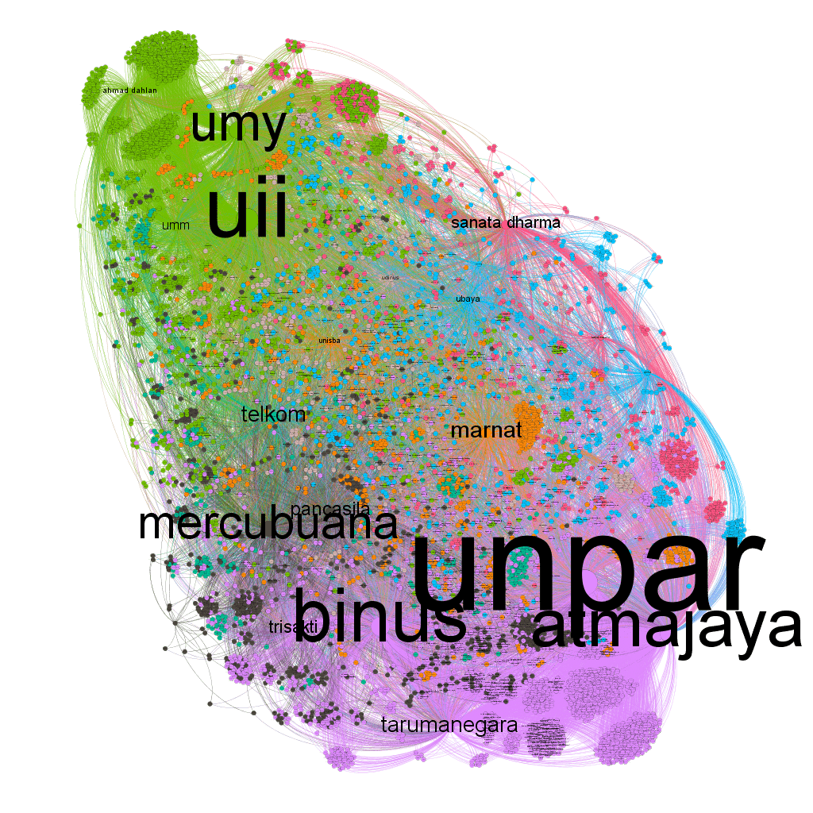

Contoh implementasi SNA dalam melihat persebaran folowers Instagram & clustering dari 22 PTS terbaik di Indonesia

# Areas of Implementation

## Case Studies

Business - Social media market segmentation  
- Information spreading through network  
- Identify prominent person of a society(for endorsment)  
- Mapping tourism flow  
- Mapping potential consumer by whole network industry  
-

Non Business - Analyzing how something goes viral in social media  
- finding best influencer in certain situation  
- Word embedding stuff  
- implementation of [small-world theory](https://en.wikipedia.org/wiki/Small-world_experiment) and [six degree separation of Kevin Bacon](https://en.wikipedia.org/wiki/Six_degrees_of_separation)

## Potential Uses

- For Algoritma itself:
  - mapping our potential consumer in social media. for example: gather (scrap) all person who follow similar industry like Algoritma (decoding, dqlab, udemy, lambda school, etc). From `that person`, gather all of their followin then calculate `Betwenness centrality`, `eigen vector`, `page rank`, `closeness centrality` (metrics you’ll learn in SNA) from their network. thus you’ll get list of person who, which is considered based on SNA metrics calculation, is the best person who can spread information fast, wide, and effective.
  - its also can be implemented through every indsutry who have market in social media
- Analyze viral things in social media and help our marketers create similiar content
- Finding best `endorser` in social media

## How to do it:

note: belum pernah SNA complex di R. jadi ini gambaran besar yang aku tau  
- build Twitter data scrapper (streaming and not)  
- find out how create `nodes` and `edges` dataframe from raw twitter data from `rtweet` library  
- create network and visualize it as fancy as you can  
- create clustering from network and implement it on network  
- Analyze SNA (all availiable metric)

# Comparison on other algorithm/app

## Similiar app:

- Gephi: An open-source software created especially for network analysis
  - pros: easy to use, fancy visualization, lots of plugin, easy metrics calculation
  - cons: RAM killer (seriously tho), community is dead since 2016 (no new plugin), minimum flexibility

## So why R?

supported library for doing SNA in R

```r
library(tidyverse) #for data wrangling. very helpfull for preparing nodes and edges data
library(network)
library(igraph)
library(tidygraph)
library(ggraph)
library(visNetwork)
library(networkD3)
# for twitter
library(rtweet)
```

- Pros:
  - high flexibility and customization for analysis
  - Dashboard like `shinny` will very helpfull for public use (documentation)
  - Computer-friendly (it’ll not harm our pc as hurt as other apps :( )
  - Can be combined with other ML/algorithm. for example: creat clustering (kmeans etc) from builded network
- Cons:
  - Coding (when other apps can easily just drag and drop)
  - standard visualization
  - minimun troubleshoot in the internet

# Additional notes:

- Why Twitter: i have Twitter API and used to retrieve data from Twitter (using R)
- Why SNA: My previous lab research and mentor are focused on this studies. There’s plenty of project i’ve already done using SNA and social media analysis
- Reserch about SNA has never been done in Algoritma (please correct me if i wrong)

# References:

- [R Network Introdction](http://pablobarbera.com/big-data-upf/html/02a-networks-intro-visualization.html)
- [Newest SNA tools for R](https://www.jessesadler.com/post/network-analysis-with-r/)
- [Drone Empirit](https://pers.droneemprit.id/) My favourite non-business implementation of SNA. They are bunch of journalist who write news/article usign SNA
- My previous mata kuliah about big data (i hope i can tag it here :( )
- [My research about using SNA in crisis communication (terrorist attack in new zealand)](https://www.researchgate.net/publication/338943208_Crisis_Communication_on_Twitter_A_Social_Network_Analysis_of_Christchurch_Terrorist_Attack_in_2019)
- [Instagram Ego Network](https://medium.com/@joenathanchristian/instagram-social-network-visualization-e1753a4d75a3) my research about finding out *small-world* theory in my own Instagram ego network